# Depth Analysis in Native Space

# Analytical strategy

Previously I quantified the distribution of the **count** of suprathreshold voxels for each depth bin.

This is however likely *not* the best option since the count does not reflect the magnitude of the parameter estimate for a given contrast.

The best would be to use the COPEs directly, but in this case there would be huge problems with the variability across runs.

**In this notebook, I calculate for each cortical bin the mean (and sderr) of the thresholded zstat for all the voxels in that cortical depth. Then I will use these estimates in a group-level analysis for each depth bin in each ROI across participants.**

The choice of using the thresholded zstat instead of the raw zstat is twofold: - first the thresholded zstat are already present only on the map of cortical depth, which is where I want to estimate my statistic - second, the thresholded zstat have already been corrected for MCP

Of course I will also here have the problem that in some sub/ROIs there will be no voxels > zthr.

**Notation**: D = Depth, JU = Juelich atlas/region, Z = Z-statistic image from the GLM

## Select sub and Zcontrast, and choose thresholds and number of D bins

This part will go at the end once all the functions are defined

```r
# User-defined parameters, which will become selector widgets

# SUBID = "sub_02"     # df %>% distinct(sub) to see all available sub
# Zcontrast <- "thresh_zstat1"
# zthr <- 3.1  # use smallcap to indicate that it is a scalar
# clusterSizeThr <- 100  # to build a meaningful histogram
# nbin <- 20 # set hist breaks to a fixed range
# thr_N_taskruns <- 4 # in how many taskruns (>2) should I find sig clusters, to consider it interesting?



# -----------------------------------------------------------------------------

# Immutable parameters
gitdir <- "/data00/layerfMRI/Github_repo/"
bd <- paste0(gitdir,"layerfMRI/analyses/depth_native/")

library(RNifti)
library(stringr)
library(tidyr)
library(dplyr)
library(purrr)
select <- dplyr::select
library(tibble)
library(ggplot2)
library(ggthemes)
library(tictoc)


julabels <- read.csv("labels_juelich.csv") %>%
  mutate(name = str_replace(name,"['-/]","")) %>%    # get rid of special chars
  mutate(numba = index + 1) %>%
  select(-index)
```

## Create dictionary of data from `list.files`

The magic is provided by `tidyr::separate`

```r
create_dizio_files <- function(data_native_dir = "data_native") {

  df <- list.files("data_native", recursive = T) %>% as.data.frame()
  names(df) <- "fname"


  df <- df %>%
    rowwise() %>%
    tidyr::separate(
      fname, c("sub","contrast","taskrun","zstat"),
      sep = "/", fill = "right", remove = FALSE
    ) %>%
    mutate(taskrun = str_extract(taskrun,"task_[1-4]\\_run_[1-2]")) %>%
    mutate(zstat = str_extract(zstat,"thresh_zstat[1-4]")) %>%
    mutate(pathname = paste0(bd,"/data_native/",fname)) %>%
    dplyr::select(-fname)

  return(df)
}



# ------------------------------  Code for Main -------------------------------
# df <- create_dizio_files()

df <- create_dizio_files()
# show df tree
library(collapsibleTree)
dataset <- df %>% dplyr::select(sub,contrast,taskrun,zstat)
collapsibleTree(dataset, c("sub","contrast","taskrun","zstat"), collapsed = T, zoomable = F)
```

[interactive chart not shown]

## Load Z, D, JU and extract values for Z sig voxels within JU ROIs

Load the nii for Zstat[contrast], Depth and JUelich atlas for all 8 taskruns, all in native space:

- Z_nii : 8 for each contrast (Motion, Scrambled, M>S, S>M)
- D_nii : 8, one for each taskrun
- JU_nii : 8, one for each taskrun

Then for each run/contrast 1. threshold the Z_nii to zthr and create a Zthr_idx of suprathreshold voxels 2. extract Z_vals, D_vals and JU_vals at the locations of Zthr_idx 3. purrr Z, D, JU vals into a list of tibbles (8) 4. retain for each taskrun/tibble only the Z and D vals where JU > 0 - i.e. inside JU ROIs

**NB**: the two functions are separate so that I don’t need to reload the niis if I choose another Z threshold

```r
load_niis <- function(SUBID, Zcontrast) {

  # Load the Z_nii for a given contrast (8, one for each taskrun)
  Z_nii <- df %>%
    filter(sub == SUBID, contrast == "Zstat", zstat == Zcontrast) %>%
    select(pathname) %>% sapply(readNifti)

  # Load the D_nii (8 taskrun)
  D_nii <- df %>%
    filter(sub == SUBID, contrast == "depth") %>%
    select(pathname) %>% sapply(readNifti)

  # Load the JU_nii (8 taskrun)
  JU_nii <- df %>%
    filter(sub == SUBID, contrast == "atlas") %>%
    select(pathname) %>% sapply(readNifti)

  niis <- list(Z = Z_nii, D = D_nii, JU = JU_nii)

  return(niis)
}


get_Z_D_JU_vals <- function(zthr, Z_nii, D_nii, JU_nii) {

  # Create an index of sig voxels, i.e. whose value is > zthr
  Zthr_idx <- sapply(Z_nii, function(x) {which(x > zthr)})

  # Extract Z, D, JU values at the location of Zthr_idx
  Z_vals <- mapply( function(vols,idx) vols[idx], Z_nii, Zthr_idx )
  D_vals <- mapply( function(depth,idx) depth[idx], D_nii, Zthr_idx )
  JU_vals <- mapply( function(atlas,idx) atlas[idx], JU_nii, Zthr_idx )

  # Purrr everything into a list of tibbles and retain only D,Z values
  # inside JU ROIs
  vals <- pmap(
    list(Z_vals, D_vals, JU_vals),
    function(Z,D,JU) tibble(Z,D,JU) %>% filter(JU > 0)
  )


  return(vals)
}


# ------------------------------  Code for Main -------------------------------

# # Load Z, D, JU and extract values for Z sig voxels within JU ROIs
# niis <- load_niis(SUBID, Zcontrast)
# vals <- get_Z_D_JU_vals(zthr, niis$Z, niis$D, niis$JU)
```

## Get mean Z for each D bin in each JU region in each taskrun

Here we create a function using the pipeline developed above, and we map it to each subtibble in `vals`, i.e. to the tibble referring to each taskrun.

For each taskrun we will `map` the following procedure:

```r
get_meanZ <- function(vals, clusterSizeThr, nbin) {

  ALL_taskruns_meanZ <- vals %>%
    group_by(JU) %>%                    # 1. group_by JU ROI
    mutate(nvox = n()) %>%              # 2. count numba vox in each JU ROI
    arrange(nvox, JU) %>%               # sort by ascending nvox, just to check
    filter(nvox > clusterSizeThr) %>%   # 3. remove JU with nvox < clusterSizeThr
    group_split() %>%                   # 4. split: one for each JU ROI
    map(~ .x %>% mutate(D_bins = ntile(D, nbin) %>% as.factor) %>% arrange(D) ) %>%  # 5. Depth bins
    map(~ .x %>% group_by(D_bins) ) %>% # 6. group values by ntile
    map(~ .x %>% summarise(             # 7. calculate mean Z for each ntile of D
      mean_Z = mean(Z),
      # sd_Z = sd(Z),
      JU = mean(JU),
      .groups = "drop"
    )) %>%
    bind_rows()                         # 8. put the summary of all the JU ROIs

  return(ALL_taskruns_meanZ)
}


# # To test the function and plot the results for one taskrun only:
# ALL_taskruns_meanZ <- map(list(vals[[1]]), get_meanZ)
#
# ALL_taskruns_meanZ %>% as.data.frame() %>%
#   ggplot( aes(x = as.numeric(D_bins), y = mean_Z, fill = as.numeric(D_bins)) ) +
#   geom_bar(stat = "identity", width = 1) +
#   coord_cartesian(ylim = c(1.9, zthr + 2)) +
#   facet_wrap(~ JU, scales = "free")


# ------------------------------  Code for Main -------------------------------

# # Get mean Z for each D bin in each JU region in each taskrun
# # 1. extract the metric of interest for each taskrun (madonna!)
# ALL_taskruns_meanZ <- map(vals, ~ get_meanZ(.x, clusterSizeThr, nbin))
#
# # 2. assign a taskrun column - for further averaging - and bind_rows all together
# ALL_taskruns_meanZ <- pmap(
#   list(1:length(ALL_taskruns_meanZ), ALL_taskruns_meanZ),
#   function(nth_taskrun, df_taskrun) df_taskrun %>% mutate(taskrun = nth_taskrun)
# ) %>% bind_rows()
```

## Average the mean Z in each D bin across taskruns

1. Before averaging, include only ROIs where sig clusters where found in an acceptable numba of runs, for instance at least 4/8
2. Split the tibble in N tibbles, where N is the numba of JU ROI with sig clusters in at least n_aboveThr_taskrun
3. For each ROI (map) group the mean_Z values by bin, so that you will be able to estimate the average mean_Z for each Depth bin across taskruns
4. Calculate the mean and sd of mean_Z (<- this was the mean_Z in the single taskrun) across taskruns. **This is the quantity that will be taken to the group-level analysis**
5. Finally, bind the results for all ROIs in a single tibble

```r
get_MEAN_taskruns_meanZ <- function(ALL_taskruns_meanZ, thr_N_taskruns) {

  MEAN_taskruns_meanZ <- ALL_taskruns_meanZ %>%
    group_by(JU) %>%                       # again, everything is JU ROI-specific
    mutate(n_aboveThr_taskrun = n_distinct(taskrun)) %>%
    filter(n_aboveThr_taskrun >= thr_N_taskruns) %>%   # 1. filter ROI < n_aboveThr_taskrun
    group_split() %>%                      # 2. split ROIs
    map(~ .x %>% group_by(D_bins) ) %>%    # 3. group by D bin across taskruns for each ROI
    map(~ .x %>% summarise(                # 4. get the mean_Z for each D
      TR_mean_Z = mean(mean_Z),
      sd_Z = sd(mean_Z),
      JU = mean(JU),
      .groups = "drop"
    )) %>% bind_rows()

  return(MEAN_taskruns_meanZ)

}

# # Test plotting the result for one subject and one contrast:
# MEAN_taskruns_meanZ %>%
#   ggplot( aes(x = as.numeric(D_bins), y = TR_mean_Z, fill = as.numeric(D_bins)) ) +
#   geom_bar(stat = "identity", width = 1) +
#   geom_linerange( aes(ymin = TR_mean_Z - sd_Z, ymax = TR_mean_Z + sd_Z) ) +
#   coord_cartesian(ylim = c(zthr - 1, zthr + 2)) +
#   facet_wrap(~ JU, scales = "free")

# ------------------------------  Code for Main -------------------------------

# # Average the mean Z in each D bin across taskruns
# MEAN_taskruns_meanZ <- get_MEAN_taskruns_meanZ(ALL_taskruns_meanZ, thr_N_taskruns)
```

## Main function for each subject and each contrast

```r
get_results <- function(SUBID, Zcontrast, zthr, clusterSizeThr, nbin, thr_N_taskruns) {

  # 1. Load Z, D, JU and extract values for Z sig voxels within JU ROIs
  niis <- load_niis(SUBID, Zcontrast)
  vals <- get_Z_D_JU_vals(zthr, niis$Z, niis$D, niis$JU)

  # Get mean Z for each D bin in each JU region in each taskrun
  # 1. extract the metric of interest for each taskrun (madonna!)
  ALL_taskruns_meanZ <- map(vals, ~ get_meanZ(.x, clusterSizeThr, nbin))

  # 2. assign a taskrun column - for further averaging - and bind_rows all together
  ALL_taskruns_meanZ <- pmap(
    list(1:length(ALL_taskruns_meanZ), ALL_taskruns_meanZ),
    function(nth_taskrun, df_taskrun) df_taskrun %>% mutate(taskrun = nth_taskrun)
  ) %>% bind_rows()

  # 3. Average the mean Z in each D bin across taskruns
  MEAN_taskruns_meanZ <- get_MEAN_taskruns_meanZ(ALL_taskruns_meanZ, thr_N_taskruns)

  return(MEAN_taskruns_meanZ)
}
```

## Run for all subjects and all contrasts

To run the group-level analysis, first set the general parameters:

- zthr : Z threshold for voxels to be considered sig
- clusterSizeThr : minimum cluster size
- nbin : number of bins to sample Depth
- thr_N_taskruns : for each JU ROI, in how many taskruns (>2) should I find sig clusters, to consider it interesting?

Then the following is run, from inner to outer map: 1. run `get_results()` for one subs (inner `map2`) 2. create a column with the contrast name (`map2(contrast_list, names(contrast_list))`) 3. concatenate the Motion and Scrambled tibbles by rows 4. run the estimation for all subs (outer `map`) and concatenate all subs by rows (note that we don’t need the sub ID so it’s left out)

```r
df <- create_dizio_files()

# SUBID = "sub_02"     # df %>% distinct(sub) to see all available sub
# Zcontrast <- "thresh_zstat1"
zthr <- 2.3  # use smallcap to indicate that it is a scalar
clusterSizeThr <- 50  # to build a meaningful histogram
nbin <- 10 # set hist breaks to a fixed range
thr_N_taskruns <- 4 # in how many taskruns (>2) should I find sig clusters, to consider it interesting?


contrast_list <- list(
  Motion = "thresh_zstat1",
  Scrambled = "thresh_zstat2"
)

# NB: sub_14 is FU for thresh_zstat2: not even in one run there are sig voxels at ztr > 3.1

# ~ 20 sec to go through ~ 300 nifti files. Not bad.

all <- map(
  df$sub %>% unique(),
  function(onesub) map2(
    contrast_list, names(contrast_list),
    function(contrast,name) {
      get_results(SUBID = onesub, contrast,
                  zthr, clusterSizeThr, nbin,
                  thr_N_taskruns) %>%
        mutate(contrast = name)
    }
  ) %>% reduce(bind_rows)
) %>% reduce(bind_rows)


# all
```

## Average the results across subjects and plot

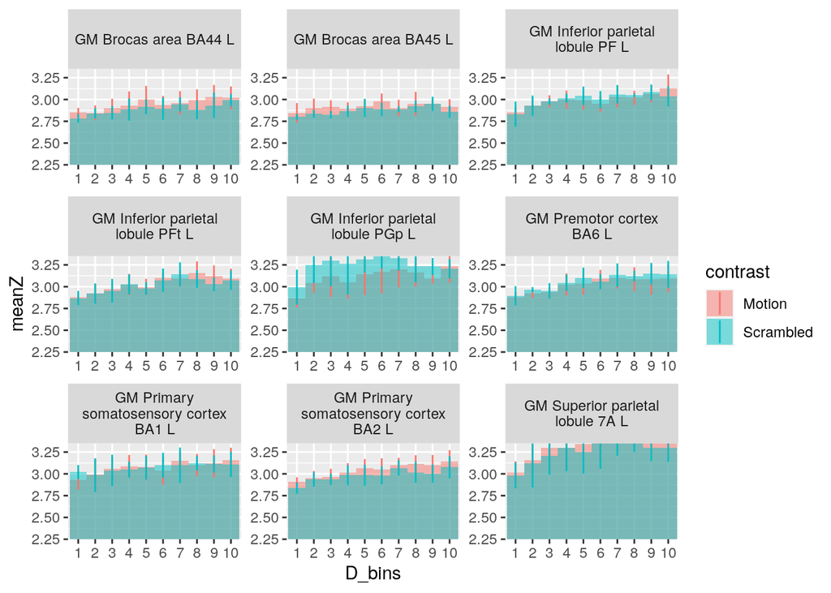

```r
thr_N_subs = 4

group_avg <- all %>%
  select(-sd_Z) %>%
  group_by(contrast, JU, D_bins) %>%
  mutate(n_sub_sig = n()) %>%
  filter(n_sub_sig >= thr_N_subs) %>%
  summarise(
    meanZ = mean(TR_mean_Z),
    sdZ = sd(TR_mean_Z),
    .groups = "drop"
  )


group_avg %>%
  inner_join(., julabels, by = c("JU"="numba")) %>%
  mutate(name = str_replace_all(name, "_", " ")) %>%
  ggplot( aes(x = D_bins, y = meanZ, fill = contrast) ) +
  geom_bar(stat = "identity", width = 1, position = position_identity(), alpha = 0.5) +
  geom_linerange( aes(ymin = meanZ - sdZ, ymax = meanZ + sdZ, color=contrast) ) +
  coord_cartesian(ylim = c(zthr, zthr + 1)) +
  facet_wrap(~ name, scales = "free", labeller = label_wrap_gen(width=22))
```